# Wykorzystanie modelu skłonności do odpowiedzi i ważenia danych

# 1 Procedura estymacji – modelowanie $R_i$ oraz ważenie danych

## 1.1 Model skłonności do odpowiedzi

W naszym przypadku odpowiedzieli jedynie internauci, co oznacza, że model skłonności do odpowiedzi jest jednocześnie modelem korekty pokrycia

$$P(I_i=1 | \boldsymbol{X}_i) = P(R_i=1 | \boldsymbol{X}_i, I_i=1) = \rho_i$$

## 1.2 Ważenie danych

Niestety, w momencie kiedy użyjemy te wagi wielkosci populacji nie będą się zgadzały w odpowiednich przekrojach

$$\sum_{i=1}^{n_r} \rho_i \neq N,$$
gdzie $N$ to wielkość populacji. Tym bardziej widoczne to będzie w przypadku podpopulacji np. kobiet czy mężczyzn. Dlatego należy przeprowadzić odpowiednie korekty $\rho_i$, tak aby uzyskać nowe wagi $d_i$, które użyjemy do ważenia naszej próby.

Możemy do tego wykorzystać:

- post-stratyfikację -> oszacowanie średniej i przeważenie przez,
- kalibrację -> waga dla każdej jednostki oddzielnie **to dziś zrobimy**.

# 2 Przykład empiryczny

## 2.1 Wczytanie danych

Wczytujemy, tworzymy nowe zmienne, nadajemy etykiety i ograniczamy do ograniczamy dane tylko do osób w wieku 15-59 lat i pracujacych

```r
load('../data/diagnoza2015.rdata')
diagnoza2015$internet <- ifelse(diagnoza2015$internet == 1, 1, 0)
diagnoza2015$praca <- ifelse(diagnoza2015$czy_praca == 1,1,0)
## nadajemy etykiety
diagnoza2015$plec <- factor(
  x = diagnoza2015$plec,
  levels = 1:2,
  labels = c('Mezczyzna','Kobieta'),
  ordered = FALSE
)
diagnoza2015$klm <- factor(
  x = diagnoza2015$klm,
  levels = 1:6,
  labels = c('500k+', '200k-500k','100k-200k', '20k-100k','ponizej 20k', 'wies'),
  ordered = FALSE
)
diagnoza2015$woj <- factor(
  x = diagnoza2015$woj,
  levels = seq(2,32,2),
  labels = c(
    'Dolnośląskie','Kujawsko-Pomorskie',
    'Lubelskie','Lubuskie','Łódzkie',
    'Małopolskie','Mazowieckie','Opolskie','Podkarpackie',
    'Podlaskie','Pomorskie','Śląskie',
    'Świętokrzyskie','Warmińsko-Mazurskie',
    'Wielkopolskie','Zachodniopomorskie'),
  ordered = FALSE)
diagnoza2015$klm <- relevel(diagnoza2015$klm,ref = 'wies')
diagnoza2015 <- subset(diagnoza2015, wiek <= 59 & praca == 1) ## ograniczamy dane tylko do osób w wieku 15-59 lat i pracujacych
diagnoza2015
```

| id_gosp | id_osoba | woj | klm | plec | internet | wyksz | nauka_lata | czy_praca | czy_pelny_etat | czy_rej_pup | dzieci | wiek | praca |
| --- | --- | --- | --- | --- | --- | --- | --- | --- | --- | --- | --- | --- | --- |
| 2 | 3 | Dolnośląskie | wies | Kobieta | 1 | 50 | 10 | 1 | 1 | 2 | 1 | 53 | 1 |
| 12 | 1 | Dolnośląskie | wies | Mezczyzna | 1 | 50 | 11 | 1 | 1 | 2 | 1 | 50 | 1 |
| 12 | 7 | Dolnośląskie | wies | Mezczyzna | 1 | 30 | 13 | 1 | 1 | 2 | 1 | 35 | 1 |
| 12 | 2 | Dolnośląskie | wies | Kobieta | 1 | 50 | 11 | 1 | 2 | 2 | 1 | 50 | 1 |
| 56 | 1 | Dolnośląskie | 500k+ | Mezczyzna | 1 | 40 | 12 | 1 | 1 | 2 | 1 | 56 | 1 |
| 58 | 4 | Dolnośląskie | 500k+ | Kobieta | 1 | 20 | 15 | 1 | 1 | 2 | 1 | 38 | 1 |
| 90 | 7 | Dolnośląskie | wies | Mezczyzna | 1 | 50 | 11 | 1 | 1 | 2 | 1 | 37 | 1 |
| 90 | 4 | Dolnośląskie | wies | Kobieta | 1 | 50 | 11 | 1 | 1 | 2 | 0 | 29 | 1 |
| 90 | 5 | Dolnośląskie | wies | Kobieta | 1 | 30 | 12 | 1 | 1 | 2 | 0 | 20 | 1 |
| 95 | 1 | Dolnośląskie | wies | Mezczyzna | 1 | 50 | 11 | 1 | 1 | 2 | 1 | 44 | 1 |

[output cut: 190 more lines]

## 2.2 Budujemy model

Budujemy następujący model, którym objaśniamy dostęp do internetu (oczywiscie należałoby go dokładnie sprawdzić!!!!!!)

$$P(I_i = 1 | plec_i + wiek_i + klm_i + dzieci_i + woj_i),$$
gdzie $plec_i$ to płeć respondenta, $wiek_i$ wiek respondenta, $klm_i$ klasa wielkości miejscowości, $dzieci_i$ czy posiada dzieci, $woj_i$ to województwo zamieszkania.

```r
model <- glm(internet ~ plec + wiek + klm + dzieci + woj,
             data = diagnoza2015,
             family = binomial())
summary(model)
```

```
Call:
glm(formula = internet ~ plec + wiek + klm + dzieci + woj, family = binomial(),
    data = diagnoza2015)

Deviance Residuals:
    Min       1Q   Median       3Q      Max
-3.0797   0.1618   0.3816   0.6614   1.7027

Coefficients:
                        Estimate Std. Error z value Pr(>|z|)
(Intercept)             5.251218   0.188438  27.867  < 2e-16 ***
plecKobieta             0.225729   0.056678   3.983 6.81e-05 ***
wiek                   -0.102503   0.003144 -32.605  < 2e-16 ***
klm500k+                2.198163   0.177470  12.386  < 2e-16 ***
klm200k-500k            1.930070   0.152066  12.692  < 2e-16 ***
klm100k-200k            1.628482   0.157902  10.313  < 2e-16 ***
klm20k-100k             1.163829   0.085967  13.538  < 2e-16 ***
klmponizej 20k          0.936422   0.093449  10.021  < 2e-16 ***
dzieci                  0.152967   0.057724   2.650 0.008049 **
wojKujawsko-Pomorskie  -0.220008   0.168545  -1.305 0.191778
wojLubelskie           -0.238940   0.149351  -1.600 0.109631
wojLubuskie             0.187821   0.211950   0.886 0.375532
wojŁódzkie             -0.378201   0.150700  -2.510 0.012086 *
wojMałopolskie          0.328680   0.160323   2.050 0.040353 *
wojMazowieckie         -0.234305   0.137645  -1.702 0.088711 .
wojOpolskie             0.509012   0.214082   2.378 0.017423 *
wojPodkarpackie        -0.061924   0.158280  -0.391 0.695628
wojPodlaskie           -0.419311   0.176542  -2.375 0.017543 *
wojPomorskie            0.120670   0.176168   0.685 0.493364
wojŚląskie             -0.161465   0.152528  -1.059 0.289785
wojŚwiętokrzyskie      -0.521482   0.162371  -3.212 0.001320 **
wojWarmińsko-Mazurskie -0.590719   0.157458  -3.752 0.000176 ***
wojWielkopolskie       -0.150883   0.150714  -1.001 0.316769
wojZachodniopomorskie  -0.110045   0.195216  -0.564 0.572954
---
Signif. codes:  0 ‘***’ 0.001 ‘**’ 0.01 ‘*’ 0.05 ‘.’ 0.1 ‘ ’ 1

(Dispersion parameter for binomial family taken to be 1)

    Null deviance: 10164.8  on 9707  degrees of freedom
Residual deviance:  8051.1  on 9684  degrees of freedom
AIC: 8099.1

Number of Fisher Scoring iterations: 5
```

```r
car::Anova(model,type = 2)
```

```
Analysis of Deviance Table (Type II tests)

Response: internet
       LR Chisq Df Pr(>Chisq)
plec      15.89  1  6.698e-05 ***
wiek    1382.19  1  < 2.2e-16 ***
klm      642.86  5  < 2.2e-16 ***
dzieci     7.02  1   0.008073 **
woj       83.12 15  1.867e-11 ***
---
Signif. codes:  0 ‘***’ 0.001 ‘**’ 0.01 ‘*’ 0.05 ‘.’ 0.1 ‘ ’ 1
```

Sprawdzamy jaki rozkład ma $\hat{\boldsymbol{\rho}}$ z wykorzystaniem funkcji `hist`.

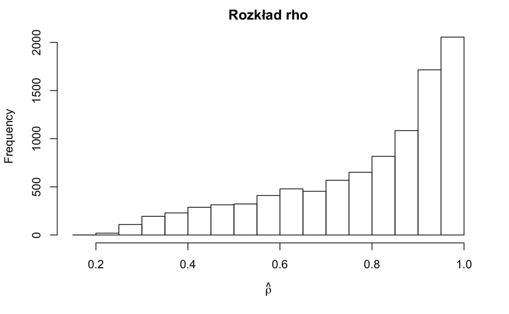

```r
hist(fitted(model), main = 'Rozkład rho', xlab = expression(hat(rho)))
```

## 2.3 Wczytujemy dane dotyczące wielkości populacji

Wczytujemy dane o populacji – wykorzystujemy je do ważenia

```r
populacja <- readxl::read_excel('../data-raw/populacja_2015.xlsx', sheet = 2)
populacja <- populacja[,c('Wiek','Płeć','Wartosc')]
populacja
```

| Wiek | Płeć | Wartosc |
| --- | --- | --- |
| 15-19 | ogółem | 120935 |
| 15-19 | mężczyźni | 62219 |
| 15-19 | kobiety | 58716 |
| 20-24 | ogółem | 150797 |
| 20-24 | mężczyźni | 76844 |
| 20-24 | kobiety | 73953 |
| 25-29 | ogółem | 170774 |
| 25-29 | mężczyźni | 87128 |
| 25-29 | kobiety | 83646 |
| 30-34 | ogółem | 199140 |

[output cut: 190 more lines]

Jaka jest wielkość populacji? N=2387.9721 $\times$ 10 tys.

## 2.4 Kalibracja

Teraz musimy dopisać odpowiednie wagi dla respondentów ze względu na płeć oraz wiek. Co musimy zrobić?

```r
table(populacja$Wiek)
```

```
15-19 20-24 25-29 30-34 35-39 40-44 45-49 50-54 55-59
   48    48    48    48    48    48    48    48    48
```

```r
table(diagnoza2015$wiek) ## wiek mamy niepogrupowany
```

```
 17  18  19  20  21  22  23  24  25  26  27  28  29  30  31  32  33  34  35  36  37  38  39  40  41  42  43  44  45  46  47  48
 10  13  25  45 114 105 134 166 227 188 200 204 220 216 253 240 244 248 255 260 256 254 292 277 266 282 274 282 278 268 257 284
 49  50  51  52  53  54  55  56  57  58  59
265 294 293 293 262 266 310 284 291 274 239
```

Dokonujemy kategoryzacji zmiennej z użyciem funkcji `cut`

```r
diagnoza2015$wiek_grupy <- cut(x = diagnoza2015$wiek,
                               breaks = seq(15,60,by = 5), ## wartości graniczne
                               include.lowest = TRUE, ## czy ma być zamkniety z dołu
                               labels = c('15-19', '20-24',
                                          '25-29', '30-34', '35-39',
                                          '40-44', '45-49', '50-54', '55-59'), ## przedziały
                               right = FALSE) ## czy ma być zamknięty z góry (prawa strona)
diagnoza2015$wiek_grupy <- as.character(diagnoza2015$wiek_grupy) ## zamieniamy na character
table(diagnoza2015$wiek_grupy)
```

```
15-19 20-24 25-29 30-34 35-39 40-44 45-49 50-54 55-59
   48   564  1039  1201  1317  1381  1352  1408  1398
```

Dla łatwiejszego łączenia inaczej zapisujemy płeć

```r
diagnoza2015$plec_grupa <- ifelse(diagnoza2015$plec == 'Kobieta','k','m')
table(diagnoza2015$plec_grupa)
```

```
   k    m
4824 4884
```

```r
populacja_wagi <- aggregate(Wartosc ~ Płeć + Wiek,
                            data = populacja,
                            FUN = sum,
                            subset = Płeć != 'ogółem')
colnames(populacja_wagi) <- c('plec','wiek','N_pop')
populacja_wagi$plec <- ifelse(populacja_wagi$plec == 'kobiety','k','m')
populacja_wagi
```

| plec | wiek | N_pop |
| --- | --- | --- |
| k | 15-19 | 964181 |
| m | 15-19 | 1013535 |
| k | 20-24 | 1182251 |
| m | 20-24 | 1229032 |
| k | 25-29 | 1392240 |
| m | 25-29 | 1440223 |
| k | 30-34 | 1600190 |
| m | 30-34 | 1645284 |
| k | 35-39 | 1531920 |
| m | 35-39 | 1570926 |

[output cut: 8 more lines]

Łączymy dane

```r
do_estymacji <- merge(x = diagnoza2015,
                      y = populacja_wagi,
                      by.x = c('wiek_grupy','plec_grupa'),
                      by.y = c('wiek','plec'),
                      all.x = T)
do_estymacji <- subset(do_estymacji, internet == 1)
do_estymacji
```

|  | wiek_grupy | plec_grupa | id_gosp | id_osoba | woj | klm | plec | internet | wyksz | nauka_lata | czy_praca | czy_pelny_etat | czy_rej_pup | dzieci | wiek | praca | N_pop |
| --- | --- | --- | --- | --- | --- | --- | --- | --- | --- | --- | --- | --- | --- | --- | --- | --- | --- |
| 1 | 15-19 | k | 289 | 8 | Kujawsko-Pomorskie | ponizej 20k | Kobieta | 1 | 51 | 10 | 1 | 2 | 2 | 1 | 18 | 1 | 964181 |
| 2 | 15-19 | k | 39182 | 2 | Kujawsko-Pomorskie | wies | Kobieta | 1 | 51 | 11 | 1 | 2 | 2 | 0 | 19 | 1 | 964181 |
| 3 | 15-19 | k | 114882 | 1 | Zachodniopomorskie | ponizej 20k | Kobieta | 1 | 51 | 12 | 1 | 2 | 2 | 0 | 19 | 1 | 964181 |
| 4 | 15-19 | k | 39323 | 3 | Kujawsko-Pomorskie | 200k-500k | Kobieta | 1 | 51 | 11 | 1 | 2 | 2 | 0 | 18 | 1 | 964181 |
| 5 | 15-19 | k | 48297 | 3 | Wielkopolskie | 20k-100k | Kobieta | 1 | 51 | 11 | 1 | 1 | 2 | 0 | 19 | 1 | 964181 |
| 6 | 15-19 | k | 104499 | 2 | Wielkopolskie | wies | Kobieta | 1 | 51 | 10 | 1 | 2 | 2 | 0 | 17 | 1 | 964181 |
| 7 | 15-19 | k | 51044 | 3 | Lubuskie | wies | Kobieta | 1 | 51 | 11 | 1 | 2 | 2 | 1 | 19 | 1 | 964181 |
| 8 | 15-19 | k | 47106 | 7 | Świętokrzyskie | ponizej 20k | Kobieta | 1 | 51 | 9 | 1 | 2 | 2 | 0 | 19 | 1 | 964181 |
| 9 | 15-19 | k | 41619 | 7 | Małopolskie | wies | Kobieta | 1 | 51 | 12 | 1 | 1 | 2 | 0 | 19 | 1 | 964181 |
| 10 | 15-19 | k | 52887 | 5 | Opolskie | wies | Kobieta | 1 | 51 | 11 | 1 | 2 | 2 | 0 | 19 | 1 | 964181 |

[output cut: 190 more lines]

Sprawdzamy czy wagi

```r
proba_wielkosc <- aggregate(plec ~ wiek_grupy + plec_grupa,
                       data = do_estymacji,
                       FUN = length)
names(proba_wielkosc)[3] <- 'n_proba'
proba_wielkosc
```

| wiek_grupy | plec_grupa | n_proba |
| --- | --- | --- |
| 15-19 | k | 17 |
| 20-24 | k | 254 |
| 25-29 | k | 489 |
| 30-34 | k | 517 |
| 35-39 | k | 621 |
| 40-44 | k | 592 |
| 45-49 | k | 535 |
| 50-54 | k | 482 |
| 55-59 | k | 383 |
| 15-19 | m | 29 |

[output cut: 8 more lines]

Łączymy w jeden zbiór

```r
do_estymacji <- merge(do_estymacji, proba_wielkosc, all.x  = T)
do_estymacji
```

| wiek_grupy | plec_grupa | id_gosp | id_osoba | woj | klm | plec | internet | wyksz | nauka_lata | czy_praca | czy_pelny_etat | czy_rej_pup | dzieci | wiek | praca | N_pop | n_proba |
| --- | --- | --- | --- | --- | --- | --- | --- | --- | --- | --- | --- | --- | --- | --- | --- | --- | --- |
| 15-19 | k | 289 | 8 | Kujawsko-Pomorskie | ponizej 20k | Kobieta | 1 | 51 | 10 | 1 | 2 | 2 | 1 | 18 | 1 | 964181 | 17 |
| 15-19 | k | 39182 | 2 | Kujawsko-Pomorskie | wies | Kobieta | 1 | 51 | 11 | 1 | 2 | 2 | 0 | 19 | 1 | 964181 | 17 |
| 15-19 | k | 114882 | 1 | Zachodniopomorskie | ponizej 20k | Kobieta | 1 | 51 | 12 | 1 | 2 | 2 | 0 | 19 | 1 | 964181 | 17 |
| 15-19 | k | 39323 | 3 | Kujawsko-Pomorskie | 200k-500k | Kobieta | 1 | 51 | 11 | 1 | 2 | 2 | 0 | 18 | 1 | 964181 | 17 |
| 15-19 | k | 48297 | 3 | Wielkopolskie | 20k-100k | Kobieta | 1 | 51 | 11 | 1 | 1 | 2 | 0 | 19 | 1 | 964181 | 17 |
| 15-19 | k | 104499 | 2 | Wielkopolskie | wies | Kobieta | 1 | 51 | 10 | 1 | 2 | 2 | 0 | 17 | 1 | 964181 | 17 |
| 15-19 | k | 51044 | 3 | Lubuskie | wies | Kobieta | 1 | 51 | 11 | 1 | 2 | 2 | 1 | 19 | 1 | 964181 | 17 |
| 15-19 | k | 47106 | 7 | Świętokrzyskie | ponizej 20k | Kobieta | 1 | 51 | 9 | 1 | 2 | 2 | 0 | 19 | 1 | 964181 | 17 |
| 15-19 | k | 41619 | 7 | Małopolskie | wies | Kobieta | 1 | 51 | 12 | 1 | 1 | 2 | 0 | 19 | 1 | 964181 | 17 |
| 15-19 | k | 52887 | 5 | Opolskie | wies | Kobieta | 1 | 51 | 11 | 1 | 2 | 2 | 0 | 19 | 1 | 964181 | 17 |

[output cut: 190 more lines]

Tworzymy wagę kalibracyjną

$$w_{i,kal} = N_{d, pop} / n_{d, pop},$$

gdzie $N_{d, pop}$ to wielkość populacji w danej domenie (u nas płeć i wiek), a $n_{d, pop}$ to wielkość próby w tych domenach.

```r
do_estymacji$waga_kalibracja <- do_estymacji$N_pop/do_estymacji$n_proba
do_estymacji
```

| wiek_grupy | plec_grupa | id_gosp | id_osoba | woj | klm | plec | internet | wyksz | nauka_lata | czy_praca | czy_pelny_etat | czy_rej_pup | dzieci | wiek | praca | N_pop | n_proba | waga_kalibracja |
| --- | --- | --- | --- | --- | --- | --- | --- | --- | --- | --- | --- | --- | --- | --- | --- | --- | --- | --- |
| 15-19 | k | 289 | 8 | Kujawsko-Pomorskie | ponizej 20k | Kobieta | 1 | 51 | 10 | 1 | 2 | 2 | 1 | 18 | 1 | 964181 | 17 | 56716.529 |
| 15-19 | k | 39182 | 2 | Kujawsko-Pomorskie | wies | Kobieta | 1 | 51 | 11 | 1 | 2 | 2 | 0 | 19 | 1 | 964181 | 17 | 56716.529 |
| 15-19 | k | 114882 | 1 | Zachodniopomorskie | ponizej 20k | Kobieta | 1 | 51 | 12 | 1 | 2 | 2 | 0 | 19 | 1 | 964181 | 17 | 56716.529 |
| 15-19 | k | 39323 | 3 | Kujawsko-Pomorskie | 200k-500k | Kobieta | 1 | 51 | 11 | 1 | 2 | 2 | 0 | 18 | 1 | 964181 | 17 | 56716.529 |
| 15-19 | k | 48297 | 3 | Wielkopolskie | 20k-100k | Kobieta | 1 | 51 | 11 | 1 | 1 | 2 | 0 | 19 | 1 | 964181 | 17 | 56716.529 |
| 15-19 | k | 104499 | 2 | Wielkopolskie | wies | Kobieta | 1 | 51 | 10 | 1 | 2 | 2 | 0 | 17 | 1 | 964181 | 17 | 56716.529 |
| 15-19 | k | 51044 | 3 | Lubuskie | wies | Kobieta | 1 | 51 | 11 | 1 | 2 | 2 | 1 | 19 | 1 | 964181 | 17 | 56716.529 |
| 15-19 | k | 47106 | 7 | Świętokrzyskie | ponizej 20k | Kobieta | 1 | 51 | 9 | 1 | 2 | 2 | 0 | 19 | 1 | 964181 | 17 | 56716.529 |
| 15-19 | k | 41619 | 7 | Małopolskie | wies | Kobieta | 1 | 51 | 12 | 1 | 1 | 2 | 0 | 19 | 1 | 964181 | 17 | 56716.529 |
| 15-19 | k | 52887 | 5 | Opolskie | wies | Kobieta | 1 | 51 | 11 | 1 | 2 | 2 | 0 | 19 | 1 | 964181 | 17 | 56716.529 |

[output cut: 190 more lines]

```r
sum(do_estymacji$waga_kalibracja) == sum(populacja_wagi$N_pop)
```

```
[1] TRUE
```

Wagi sie zgadzają! Przy czym w ogóle jeszcze nie ruszyliśmy na podstawie $\hat{\rho}_i$ czyli $w_{i,\rho}$.

## 2.5 Dodajemy do danych wagę na podstawie $\hat{\rho}$

Przypisujemy $w_{i,\rho} = \hat{\rho}_i^{-1}$ do poszczególnych respondentów

```r
diagnoza2015$waga_rho <- 1/fitted(model)
summary(diagnoza2015$waga_rho)
```

```
   Min. 1st Qu.  Median    Mean 3rd Qu.    Max.
  1.003   1.063   1.176   1.400   1.518   5.003
```

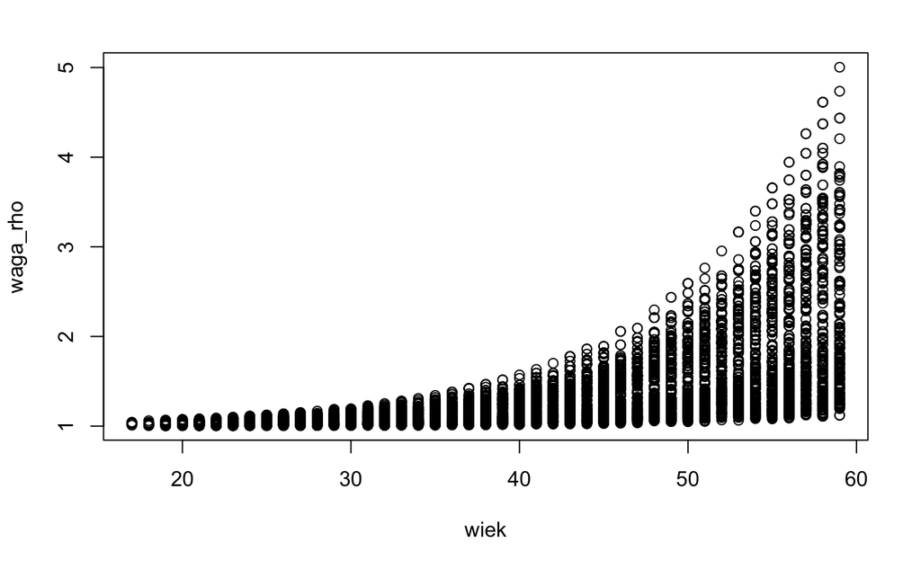

```r
## patrzymy jak wygląda waga według wieku respondenta...
plot(diagnoza2015$wiek, diagnoza2015$waga_rho,
     xlab = 'wiek',
     ylab = 'waga_rho')
```

## 2.6 Tworzymy nową wagę ostateczną

Otrzymany wektor przemnażamy razy wagę, którą oznaczymy jako $\hat{d}_{i}$

$$d_{i} = w_{i,\rho} \times w_{i,kal}$$

```r
do_estymacji$waga_rho <- diagnoza2015[diagnoza2015$internet == 1,]$waga_rho
do_estymacji$waga_final <- do_estymacji$waga_rho * do_estymacji$waga_kalibracja
sum(do_estymacji$waga_final)
```

```
[1] 30596103
```

```r
sum(populacja_wagi$N_pop)
```

```
[1] 23879721
```

Nie zgadzają sie wartości, wystarczy, że je przeskalujemy zgodnie z tym wzorem

$$d_{i}^* = d_{i} \times \frac{N}{\sum d_{i}},$$
gdzie $N$ to wielkość populacji. Poniższy kod to robi

```r
do_estymacji$waga_final <- do_estymacji$waga_final * sum(do_estymacji$waga_kalibracja)/ sum(do_estymacji$waga_final)
sum(do_estymacji$waga_final) ## wielkość populacji się zgadza 23 879 721
```

```
[1] 23879721
```

Zobaczmy jak wyglądają wagi po korekcie

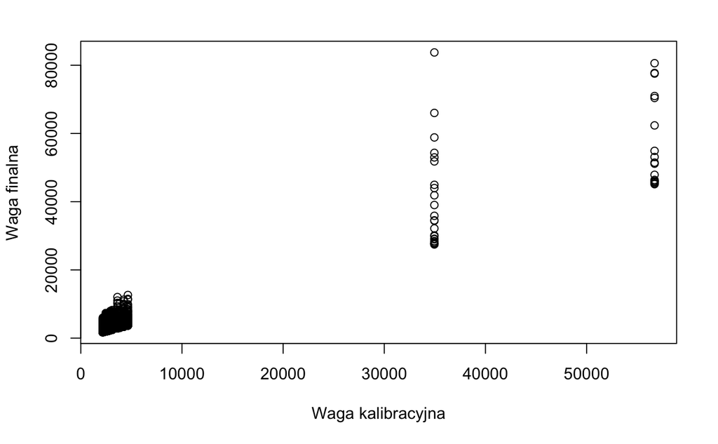

```r
plot(do_estymacji$waga_kalibracja,
     do_estymacji$waga_final,
     xlab = 'Waga kalibracyjna',
     ylab = 'Waga finalna')
```

## 2.7 Porównujemy oszacowania na podstawie wag

Porównajmy oszacowania według dwóch metod…

```r
oszacowania <- aggregate(cbind(waga_kalibracja,waga_final) ~ czy_pelny_etat, do_estymacji, FUN = sum)
prop.table(oszacowania$waga_kalibracja)*100
```

```
[1] 87.85952 12.14048
```

```r
prop.table(oszacowania$waga_final)*100
```

```
[1] 87.44546 12.55454
```

Które są bliżej prawdy? To już zadanie dla Państwa.

### 2.7.1 Czy zgadzają się wielkości populacji w domenach?

```r
aggregate(cbind(waga_kalibracja,waga_final) ~ plec_grupa, do_estymacji, FUN = sum)
```

| plec_grupa | waga_kalibracja | waga_final |
| --- | --- | --- |
| k | 11872379 | 11843315 |
| m | 12007342 | 12036406 |

```r
aggregate(cbind(waga_kalibracja,waga_final) ~ wiek_grupy, do_estymacji, FUN = sum)
```

| wiek_grupy | waga_kalibracja | waga_final |
| --- | --- | --- |
| 15-19 | 1977716 | 2074121 |
| 20-24 | 2411283 | 2429144 |
| 25-29 | 2832463 | 2857972 |
| 30-34 | 3245474 | 3204996 |
| 35-39 | 3102846 | 3149555 |
| 40-44 | 2730562 | 2730844 |
| 45-49 | 2334025 | 2338214 |
| 50-54 | 2408302 | 2334621 |
| 55-59 | 2837050 | 2760254 |

# 3 Ogólna strategia

1. Estymujemy model

$$P(I_i=1 | \boldsymbol{X}_i) = P(R_i=1 | \boldsymbol{X}_i, I_i=1) = \rho_i$$

2. Tworzymy wagę kalibracyjną (post-stratyfikacyjną) na podstawie informacji o populacji

$$w_{i,kal} = N_{d, pop} / n_{d, pop},$$

3. Tworzymy wektor wag $w_{i,\rho}$ na podstawie $\hat{\rho}_i$

$$w_{i,\rho} = \hat{\rho}_i^{-1}$$

4. Tworzymy nową wagę

$$d_{i} = w_{i,kal} \hat{\rho}_i^{-1} = w_{i,kal} w_{i,\rho}$$
5. Sprawdzamy czy zgadza się wielkość całej populacji i ją korygujemy

$$d_{i}^* = d_{i} \times \frac{N}{\sum d_{i}},$$

Uwaga: tutaj zapewniamy jedynie zgodność jeżeli chodzi o wielkość populacji, a nie wielkości domen (płeć, wiek). Jak sobie z tym poradzić? Można zastosować funkcję `laeken::calibWeights`, która pozwala na przeprowadzenie kalibracji (uogólnienie post-stratyfikacji).

```r
plec_wiek <- interaction(do_estymacji$plec_grupa,do_estymacji$wiek_grupy)
Xs <- calibVars(plec_wiek)
totals <- populacja_wagi$N_pop
d <- do_estymacji$waga_final
g <- calibWeights(X=Xs, d= d, totals = totals)
summary(g)
```

```
   Min. 1st Qu.  Median    Mean 3rd Qu.    Max.
 0.9204  0.9881  1.0058  1.0032  1.0122  1.0593
```

```r
do_estymacji$waga_final_po_kal <- do_estymacji$waga_final*g
```

```r
aggregate(cbind(waga_kalibracja,waga_final,waga_final_po_kal) ~ plec_grupa, do_estymacji, FUN = sum)
```

| plec_grupa | waga_kalibracja | waga_final | waga_final_po_kal |
| --- | --- | --- | --- |
| k | 11872379 | 11843315 | 11872379 |
| m | 12007342 | 12036406 | 12007342 |

```r
aggregate(cbind(waga_kalibracja,waga_final,waga_final_po_kal) ~ wiek_grupy, do_estymacji, FUN = sum)
```

| wiek_grupy | waga_kalibracja | waga_final | waga_final_po_kal |
| --- | --- | --- | --- |
| 15-19 | 1977716 | 2074121 | 1977716 |
| 20-24 | 2411283 | 2429144 | 2411283 |
| 25-29 | 2832463 | 2857972 | 2832463 |
| 30-34 | 3245474 | 3204996 | 3245474 |
| 35-39 | 3102846 | 3149555 | 3102846 |
| 40-44 | 2730562 | 2730844 | 2730562 |
| 45-49 | 2334025 | 2338214 | 2334025 |
| 50-54 | 2408302 | 2334621 | 2408302 |
| 55-59 | 2837050 | 2760254 | 2837050 |

```r
apply(oszacowania[,-1],2, prop.table)
```

[output not shown]